# Analysis of Customer Loan re-payment History and predicting credit risk & Customer Segmentation.

# Problem Statement

- Credit scoring is a statistical analysis performed by lenders and financial institutions to access one’s credit worthiness. The credit risk scores are used to evaluate the potential risk posed by lending money to consumers and in turn they can take decisions to mitigate losses due to bad debt.
- We are required to build the analytical framework to predict the credit risk score of each customer using the payment history and other demographic features.

# Data

- Data consists of the loan payment history and other demographic features of each customer.
- Target attribute : CreditRiskScore

# Import Data and basic data manipulation

```python
#Loading libraries
import numpy as np
import pandas as pd
import matplotlib.pyplot as plt
%matplotlib inline
plt.rcParams['figure.figsize'] = (10.0, 8.0)
import seaborn as sns
from scipy import stats
from scipy.stats import norm
```

```python
import os
os.getcwd()
os.chdir("C:\\Users\\dell\\Desktop\\PHD_ML")
os.getcwd()
```

```
'C:\\Users\\dell\\Desktop\\PHD_ML'
```

```python
train = pd.read_excel('Train-1557019772293.xlsx')
train_payment_his = pd.read_excel('Train_PaymentHistory-1557019802161.xlsx')
```

### Understanding the dataset

```python
train.head(5)
```

|  | CustomerID | DOB | Salary | ProfessionalLicensure | UtilitySpending | eCommerceAccount | SocialMediaAccount | NoOfProperties | CreditRiskScore |
| --- | --- | --- | --- | --- | --- | --- | --- | --- | --- |
| 0 | C12116 | 1969-04-22 | 1238.006112 | 0 | 492.726433 | 1 | No | 2 | 711 |
| 1 | C12117 | 1981-04-24 | 1633.000000 | 1 | 477.870359 | 1 | Yes | 1 | 767 |
| 2 | C12118 | 1970-02-10 | 1489.000000 | 0 | 351.593736 | 1 | Yes | 1 | 827 |
| 3 | C12119 | 1976-04-22 | 1241.000000 | 0 | 403.589993 | 1 | No | 1 | 795 |
| 4 | C12120 | 1975-04-24 | 1074.000000 | 1 | 406.066005 | 1 | No | 1 | 827 |

```python
train_payment_his.head(5)
```

|  | CustomerID | Current_Instalment_Sequence | Starting_Instalment | Maturity_Period | Current_Outstanding | Current_Loan_to_Appraisedvalu_Percent | CurrentInterestrate | RealEstate_Current_Inflation | GDP | UnemploymentRate | Asset_type | Urban_Development | Villa_House | Investment_SelfOccupied | Starting_outstanding | Starting_Loan_to_Appraisedvalu_Percent | StartingInterestrate | RealEstate_Starting_Inflation | Payment_Status |
| --- | --- | --- | --- | --- | --- | --- | --- | --- | --- | --- | --- | --- | --- | --- | --- | --- | --- | --- | --- |
| 0 | C12116 | 25 | 25 | 113 | 41303.42 | 24.498336 | 9.2 | 2.2629 | 2.899137 | 4.7 | No shred services | No | Yes | Self Occupancy | 45000.0 | 69.4 | 9.2 | 0.8703 | Non-Payoff/Non-Default |
| 1 | C12116 | 26 | 25 | 113 | 41061.95 | 24.483867 | 9.2 | 2.2510 | 2.151365 | 4.7 | No shred services | No | Yes | Self Occupancy | 45000.0 | 69.4 | 9.2 | 0.8703 | Non-Payoff/Non-Default |
| 2 | C12116 | 27 | 25 | 113 | 40804.42 | 24.626795 | 9.2 | 2.2239 | 2.361722 | 4.4 | No shred services | No | Yes | Self Occupancy | 45000.0 | 69.4 | 9.2 | 0.8703 | Non-Payoff/Non-Default |
| 3 | C12116 | 28 | 25 | 113 | 40483.89 | 24.735883 | 9.2 | 2.1967 | 1.229172 | 4.6 | No shred services | No | Yes | Self Occupancy | 45000.0 | 69.4 | 9.2 | 0.8703 | Non-Payoff/Non-Default |
| 4 | C12116 | 29 | 25 | 113 | 40367.06 | 24.925476 | 9.2 | 2.1737 | 1.692969 | 4.5 | No shred services | No | Yes | Self Occupancy | 45000.0 | 69.4 | 9.2 | 0.8703 | Non-Payoff/Non-Default |

```python
train.describe()
```

|  | Salary | ProfessionalLicensure | UtilitySpending | eCommerceAccount | NoOfProperties | CreditRiskScore |
| --- | --- | --- | --- | --- | --- | --- |
| count | 11093.000000 | 11093.000000 | 11093.000000 | 11093.000000 | 11093.000000 | 11093.000000 |
| mean | 4376.365891 | 0.572343 | 342.179622 | 0.522582 | 1.429550 | 627.486703 |
| std | 10439.657704 | 0.494761 | 90.487895 | 0.499512 | 0.815476 | 148.092576 |
| min | 1000.000000 | 0.000000 | 185.700917 | 0.000000 | 1.000000 | 350.000000 |
| 25% | 1392.000000 | 0.000000 | 264.933308 | 0.000000 | 1.000000 | 497.000000 |
| 50% | 1845.000000 | 1.000000 | 341.689687 | 1.000000 | 1.000000 | 641.000000 |
| 75% | 4039.015562 | 1.000000 | 420.922078 | 1.000000 | 2.000000 | 778.000000 |
| max | 412300.000000 | 1.000000 | 495.202445 | 1.000000 | 4.000000 | 830.000000 |

```python
train_payment_his.describe()
```

|  | Current_Instalment_Sequence | Starting_Instalment | Maturity_Period | Current_Outstanding | Current_Loan_to_Appraisedvalu_Percent | CurrentInterestrate | RealEstate_Current_Inflation | GDP | UnemploymentRate | Starting_outstanding | Starting_Loan_to_Appraisedvalu_Percent | StartingInterestrate | RealEstate_Starting_Inflation |
| --- | --- | --- | --- | --- | --- | --- | --- | --- | --- | --- | --- | --- | --- |
| count | 269778.000000 | 269778.000000 | 269778.000000 | 2.697780e+05 | 269778.000000 | 269778.000000 | 269778.000000 | 269778.000000 | 269778.000000 | 2.697780e+05 | 269778.000000 | 269778.000000 | 269778.000000 |
| mean | 37.644500 | 23.704264 | 135.277528 | 2.444245e+05 | 82.240253 | 6.618927 | 1.792160 | 1.203403 | 6.882192 | 2.586727e+05 | 78.131288 | 5.745037 | 1.958738 |
| std | 11.088145 | 5.337893 | 21.384173 | 2.263373e+05 | 25.576340 | 2.030486 | 0.265739 | 2.040205 | 1.967250 | 2.353700e+05 | 10.389990 | 2.821784 | 0.349696 |
| min | 1.000000 | 1.000000 | 29.000000 | 0.000000e+00 | 0.000000 | 0.250000 | 1.078300 | -4.146711 | 3.800000 | 1.046520e+04 | 50.100000 | 0.000000 | 0.757300 |
| 25% | 30.000000 | 20.000000 | 135.000000 | 9.294234e+04 | 64.643815 | 5.625000 | 1.562100 | 0.892996 | 5.000000 | 1.000000e+05 | 73.200000 | 5.250000 | 1.794500 |
| 50% | 37.000000 | 24.000000 | 141.000000 | 1.701912e+05 | 82.348070 | 6.500000 | 1.733500 | 1.692969 | 6.500000 | 1.800000e+05 | 80.000000 | 6.250000 | 2.127300 |
| 75% | 46.000000 | 28.000000 | 145.000000 | 3.465733e+05 | 101.714058 | 7.750000 | 2.006700 | 2.556052 | 9.000000 | 3.680000e+05 | 80.000000 | 7.375000 | 2.223900 |
| max | 60.000000 | 51.000000 | 200.000000 | 8.701859e+06 | 169.357840 | 37.500000 | 2.262900 | 5.132464 | 10.000000 | 8.000000e+06 | 125.000000 | 18.000000 | 2.262900 |

```python
train.count()
```

```
CustomerID               11093
DOB                      11093
Salary                   11093
ProfessionalLicensure    11093
UtilitySpending          11093
eCommerceAccount         11093
SocialMediaAccount       11093
NoOfProperties           11093
CreditRiskScore          11093
dtype: int64
```

```python
train_payment_his.count()
```

```
CustomerID                                269778
Current_Instalment_Sequence               269778
Starting_Instalment                       269778
Maturity_Period                           269778
Current_Outstanding                       269778
Current_Loan_to_Appraisedvalu_Percent     269778
CurrentInterestrate                       269778
RealEstate_Current_Inflation              269778
GDP                                       269778
UnemploymentRate                          269778
Asset_type                                269778
Urban_Development                         269778
Villa_House                               269778
Investment_SelfOccupied                   269778
Starting_outstanding                      269778
Starting_Loan_to_Appraisedvalu_Percent    269778
StartingInterestrate                      269778
RealEstate_Starting_Inflation             269778
Payment_Status                            269778
dtype: int64
```

```python
train.shape
```

```
(11093, 9)
```

```python
train_payment_his.shape
```

```
(269778, 19)
```

```python
cat_features=[i for i in train.columns if train.dtypes[i]=='object']
cat_features
```

```
['CustomerID', 'DOB', 'SocialMediaAccount']
```

```python
cat_features1=[i for i in train_payment_his.columns if train_payment_his.dtypes[i]=='object']
cat_features1
```

```
['CustomerID',
 'Asset_type',
 'Urban_Development',
 'Villa_House',
 'Investment_SelfOccupied',
 'Payment_Status']
```

```python
train._get_numeric_data().head(5)
```

|  | Salary | ProfessionalLicensure | UtilitySpending | eCommerceAccount | NoOfProperties | CreditRiskScore |
| --- | --- | --- | --- | --- | --- | --- |
| 0 | 1238.006112 | 0 | 492.726433 | 1 | 2 | 711 |
| 1 | 1633.000000 | 1 | 477.870359 | 1 | 1 | 767 |
| 2 | 1489.000000 | 0 | 351.593736 | 1 | 1 | 827 |
| 3 | 1241.000000 | 0 | 403.589993 | 1 | 1 | 795 |
| 4 | 1074.000000 | 1 | 406.066005 | 1 | 1 | 827 |

```python
train_payment_his._get_numeric_data().head(5)
```

|  | Current_Instalment_Sequence | Starting_Instalment | Maturity_Period | Current_Outstanding | Current_Loan_to_Appraisedvalu_Percent | CurrentInterestrate | RealEstate_Current_Inflation | GDP | UnemploymentRate | Starting_outstanding | Starting_Loan_to_Appraisedvalu_Percent | StartingInterestrate | RealEstate_Starting_Inflation |
| --- | --- | --- | --- | --- | --- | --- | --- | --- | --- | --- | --- | --- | --- |
| 0 | 25 | 25 | 113 | 41303.42 | 24.498336 | 9.2 | 2.2629 | 2.899137 | 4.7 | 45000.0 | 69.4 | 9.2 | 0.8703 |
| 1 | 26 | 25 | 113 | 41061.95 | 24.483867 | 9.2 | 2.2510 | 2.151365 | 4.7 | 45000.0 | 69.4 | 9.2 | 0.8703 |
| 2 | 27 | 25 | 113 | 40804.42 | 24.626795 | 9.2 | 2.2239 | 2.361722 | 4.4 | 45000.0 | 69.4 | 9.2 | 0.8703 |
| 3 | 28 | 25 | 113 | 40483.89 | 24.735883 | 9.2 | 2.1967 | 1.229172 | 4.6 | 45000.0 | 69.4 | 9.2 | 0.8703 |
| 4 | 29 | 25 | 113 | 40367.06 | 24.925476 | 9.2 | 2.1737 | 1.692969 | 4.5 | 45000.0 | 69.4 | 9.2 | 0.8703 |

```python
train_payment_his.isnull().sum(axis=0)
```

```
CustomerID                                0
Current_Instalment_Sequence               0
Starting_Instalment                       0
Maturity_Period                           0
Current_Outstanding                       0
Current_Loan_to_Appraisedvalu_Percent     0
CurrentInterestrate                       0
RealEstate_Current_Inflation              0
GDP                                       0
UnemploymentRate                          0
Asset_type                                0
Urban_Development                         0
Villa_House                               0
Investment_SelfOccupied                   0
Starting_outstanding                      0
Starting_Loan_to_Appraisedvalu_Percent    0
StartingInterestrate                      0
RealEstate_Starting_Inflation             0
Payment_Status                            0
dtype: int64
```

### Merging train and train_payment history data

```python
train1=train.set_index('CustomerID')
```

```python
lastpayment = train_payment_his.groupby('CustomerID').tail(1)
merged_df=train1.join(lastpayment.set_index('CustomerID'))
```

### *Structure of Dataset*

Check the datatype and structure of Credit_risk data

**Categorical Variable**

- SocialMediaAccount,Asset_type,Urban_Development,Villa_House,Investment_SelfOccupied,Payment_Status,eCommerceAccount, ProfessionalLicensure,NoOfProperties.

**Numeric variable**

- Age,Salary,UtilitySpending,CreditRiskScore,Current_Instalment_Sequence,Starting_Instalment,Maturity_Period,Current_Outstanding, Current_Loan_to_Appraisedvalu_Percent,CurrentInterestrate,RealEstate_Current_Inflation,GDP,UnemploymentRate,Starting_outstandin, Starting_Loan_to_Appraisedvalu_Percent,StartingInterestrate,RealEstate_Starting_Inflation.

**Target variable**

- CreditRiskScore

```python
merged_df.info()
```

```
<class 'pandas.core.frame.DataFrame'>
Index: 11093 entries, C12116 to C23208
Data columns (total 26 columns):
DOB                                       11093 non-null object
Salary                                    11093 non-null float64
ProfessionalLicensure                     11093 non-null int64
UtilitySpending                           11093 non-null float64
eCommerceAccount                          11093 non-null int64
SocialMediaAccount                        11093 non-null object
NoOfProperties                            11093 non-null int64
CreditRiskScore                           11093 non-null int64
Current_Instalment_Sequence               11093 non-null int64
Starting_Instalment                       11093 non-null int64
Maturity_Period                           11093 non-null int64
Current_Outstanding                       11093 non-null float64
Current_Loan_to_Appraisedvalu_Percent     11093 non-null float64
CurrentInterestrate                       11093 non-null float64
RealEstate_Current_Inflation              11093 non-null float64
GDP                                       11093 non-null float64
UnemploymentRate                          11093 non-null float64
Asset_type                                11093 non-null object
Urban_Development                         11093 non-null object
Villa_House                               11093 non-null object
Investment_SelfOccupied                   11093 non-null object
Starting_outstanding                      11093 non-null float64
Starting_Loan_to_Appraisedvalu_Percent    11093 non-null float64
StartingInterestrate                      11093 non-null float64
RealEstate_Starting_Inflation             11093 non-null float64
Payment_Status                            11093 non-null object
dtypes: float64(12), int64(7), object(7)
memory usage: 2.6+ MB
```

**Summary of CreditRisk data**

```python
merged_df.describe()
```

|  | Salary | ProfessionalLicensure | UtilitySpending | eCommerceAccount | NoOfProperties | CreditRiskScore | Current_Instalment_Sequence | Starting_Instalment | Maturity_Period | Current_Outstanding | Current_Loan_to_Appraisedvalu_Percent | CurrentInterestrate | RealEstate_Current_Inflation | GDP | UnemploymentRate | Starting_outstanding | Starting_Loan_to_Appraisedvalu_Percent | StartingInterestrate | RealEstate_Starting_Inflation |
| --- | --- | --- | --- | --- | --- | --- | --- | --- | --- | --- | --- | --- | --- | --- | --- | --- | --- | --- | --- |
| count | 11093.000000 | 11093.000000 | 11093.000000 | 11093.000000 | 11093.000000 | 11093.000000 | 11093.000000 | 11093.000000 | 11093.000000 | 1.109300e+04 | 11093.000000 | 11093.000000 | 11093.000000 | 11093.000000 | 11093.000000 | 1.109300e+04 | 11093.000000 | 11093.000000 | 11093.000000 |
| mean | 4376.365891 | 0.572343 | 342.179622 | 0.522582 | 1.429550 | 627.486703 | 47.129902 | 23.793293 | 136.015776 | 2.325473e+05 | 79.622365 | 6.443836 | 1.752437 | 1.527298 | 7.109970 | 2.617388e+05 | 78.412170 | 5.705653 | 1.964797 |
| std | 10439.657704 | 0.494761 | 90.487895 | 0.499512 | 0.815476 | 148.092576 | 11.762119 | 5.745528 | 21.211704 | 2.241921e+05 | 29.377392 | 2.368783 | 0.194962 | 2.020371 | 1.780019 | 2.404387e+05 | 10.307916 | 2.955798 | 0.353840 |
| min | 1000.000000 | 0.000000 | 185.700917 | 0.000000 | 1.000000 | 350.000000 | 10.000000 | 1.000000 | 29.000000 | 0.000000e+00 | 0.000000 | 1.000000 | 1.386200 | -4.146711 | 4.400000 | 1.046520e+04 | 50.100000 | 0.000000 | 0.757300 |
| 25% | 1392.000000 | 0.000000 | 264.933308 | 0.000000 | 1.000000 | 497.000000 | 38.000000 | 21.000000 | 136.000000 | 8.845483e+04 | 60.683502 | 5.125000 | 1.562100 | 1.175909 | 5.700000 | 1.036000e+05 | 74.000000 | 5.125000 | 1.794500 |
| 50% | 1845.000000 | 1.000000 | 341.689687 | 1.000000 | 1.000000 | 641.000000 | 47.000000 | 25.000000 | 141.000000 | 1.640645e+05 | 81.512926 | 6.500000 | 1.799700 | 2.443648 | 6.200000 | 1.840000e+05 | 80.000000 | 6.340000 | 2.167700 |
| 75% | 4039.015562 | 1.000000 | 420.922078 | 1.000000 | 2.000000 | 778.000000 | 60.000000 | 28.000000 | 145.000000 | 3.276908e+05 | 101.731565 | 7.875000 | 1.898200 | 2.836358 | 9.000000 | 3.690000e+05 | 80.000000 | 7.500000 | 2.223900 |
| max | 412300.000000 | 1.000000 | 495.202445 | 1.000000 | 4.000000 | 830.000000 | 60.000000 | 51.000000 | 200.000000 | 8.688101e+06 | 166.293664 | 18.000000 | 2.262900 | 4.320114 | 10.000000 | 8.000000e+06 | 125.000000 | 18.000000 | 2.262900 |

**View the 5 rows of dataset from Top**

```python
merged_df.head(5)
```

| CustomerID | DOB | Salary | ProfessionalLicensure | UtilitySpending | eCommerceAccount | SocialMediaAccount | NoOfProperties | CreditRiskScore | Current_Instalment_Sequence | Starting_Instalment | ... | UnemploymentRate | Asset_type | Urban_Development | Villa_House | Investment_SelfOccupied | Starting_outstanding | Starting_Loan_to_Appraisedvalu_Percent | StartingInterestrate | RealEstate_Starting_Inflation | Payment_Status |
| --- | --- | --- | --- | --- | --- | --- | --- | --- | --- | --- | --- | --- | --- | --- | --- | --- | --- | --- | --- | --- | --- |
| C12116 | 1969-04-22 | 1238.006112 | 0 | 492.726433 | 1 | No | 2 | 711 | 48 | 25 | ... | 8.3 | No shred services | No | Yes | Self Occupancy | 45000.0 | 69.4 | 9.20 | 0.8703 | Default |
| C12117 | 1981-04-24 | 1633.000000 | 1 | 477.870359 | 1 | Yes | 1 | 767 | 34 | 25 | ... | 5.8 | No shred services | No | Yes | Self Occupancy | 164500.0 | 70.0 | 7.50 | 1.8691 | Default |
| C12118 | 1970-02-10 | 1489.000000 | 0 | 351.593736 | 1 | Yes | 1 | 827 | 60 | 25 | ... | 5.7 | No shred services | No | Yes | Self Occupancy | 44000.0 | 52.5 | 13.00 | 0.7778 | Non-Payoff/Non-Default |
| C12119 | 1976-04-22 | 1241.000000 | 0 | 403.589993 | 1 | No | 1 | 795 | 60 | 25 | ... | 5.7 | Complex With shared services | No | No | Self Occupancy | 34800.0 | 56.9 | 12.35 | 0.7837 | Non-Payoff/Non-Default |
| C12120 | 1975-04-24 | 1074.000000 | 1 | 406.066005 | 1 | No | 1 | 827 | 60 | 25 | ... | 5.7 | No shred services | No | Yes | Self Occupancy | 61600.0 | 64.3 | 9.25 | 0.7812 | Non-Payoff/Non-Default |

5 rows × 26 columns

**View the 5 rows of dataset from Bottom**

```python
merged_df.tail(5)
```

| CustomerID | DOB | Salary | ProfessionalLicensure | UtilitySpending | eCommerceAccount | SocialMediaAccount | NoOfProperties | CreditRiskScore | Current_Instalment_Sequence | Starting_Instalment | ... | UnemploymentRate | Asset_type | Urban_Development | Villa_House | Investment_SelfOccupied | Starting_outstanding | Starting_Loan_to_Appraisedvalu_Percent | StartingInterestrate | RealEstate_Starting_Inflation | Payment_Status |
| --- | --- | --- | --- | --- | --- | --- | --- | --- | --- | --- | --- | --- | --- | --- | --- | --- | --- | --- | --- | --- | --- |
| C23204 | 1980-02-12 | 1479.701535 | 0 | 237.697174 | 1 | Yes | 1 | 423 | 60 | 28 | ... | 5.7 | No shred services | No | Yes | Self Occupancy | 136000.0 | 80.0 | 6.65 | 2.2510 | Non-Payoff/Non-Default |
| C23205 | 1979-03-21 | 1221.000000 | 0 | 188.176929 | 1 | No | 1 | 448 | 42 | 30 | ... | 9.4 | No shred services | No | Yes | Self Occupancy | 92800.0 | 80.0 | 0.00 | 2.2239 | Default |
| C23206 | 1981-02-13 | 1592.991559 | 0 | 492.726433 | 1 | No | 1 | 471 | 46 | 27 | ... | 9.0 | No shred services | No | No | Self Occupancy | 144000.0 | 90.0 | 0.00 | 2.2375 | Default |
| C23207 | 1982-02-08 | 2192.559968 | 0 | 237.697174 | 1 | No | 1 | 464 | 60 | 27 | ... | 5.7 | No shred services | No | Yes | Self Occupancy | 244000.0 | 80.0 | 0.00 | 2.2375 | Non-Payoff/Non-Default |
| C23208 | 1982-04-26 | 1694.000000 | 1 | 200.556990 | 1 | Yes | 1 | 586 | 60 | 27 | ... | 5.7 | No shred services | No | Yes | Self Occupancy | 102000.0 | 85.0 | 0.00 | 2.2375 | Non-Payoff/Non-Default |

5 rows × 26 columns

```python
merged_df.shape
```

```
(11093, 26)
```

# Dealing with Missing Data

No missing data is present

```python
#Looking unique values
print(merged_df.nunique())
```

```
DOB                                         708
Salary                                     8218
ProfessionalLicensure                         2
UtilitySpending                             126
eCommerceAccount                              2
SocialMediaAccount                            2
NoOfProperties                                4
CreditRiskScore                             481
Current_Instalment_Sequence                  51
Starting_Instalment                          39
Maturity_Period                             143
Current_Outstanding                       10961
Current_Loan_to_Appraisedvalu_Percent     10970
CurrentInterestrate                        1132
RealEstate_Current_Inflation                 51
GDP                                          51
UnemploymentRate                             31
Asset_type                                    2
Urban_Development                             2
Villa_House                                   2
Investment_SelfOccupied                       2
Starting_outstanding                       4094
Starting_Loan_to_Appraisedvalu_Percent      500
StartingInterestrate                        694
RealEstate_Starting_Inflation                70
Payment_Status                                3
dtype: int64
```

```python
merged_df.isnull().sum(axis=0)
```

```
DOB                                       0
Salary                                    0
ProfessionalLicensure                     0
UtilitySpending                           0
eCommerceAccount                          0
SocialMediaAccount                        0
NoOfProperties                            0
CreditRiskScore                           0
Current_Instalment_Sequence               0
Starting_Instalment                       0
Maturity_Period                           0
Current_Outstanding                       0
Current_Loan_to_Appraisedvalu_Percent     0
CurrentInterestrate                       0
RealEstate_Current_Inflation              0
GDP                                       0
UnemploymentRate                          0
Asset_type                                0
Urban_Development                         0
Villa_House                               0
Investment_SelfOccupied                   0
Starting_outstanding                      0
Starting_Loan_to_Appraisedvalu_Percent    0
StartingInterestrate                      0
RealEstate_Starting_Inflation             0
Payment_Status                            0
dtype: int64
```

## Understand Data

```python
import datetime as DT

now = pd.Timestamp('now')
merged_df['DOB'] = pd.to_datetime(merged_df['DOB'], format='%Y-%m-%d')
merged_df['DOB'] = merged_df['DOB'].where(merged_df['DOB'] < now,merged_df['DOB'] -  np.timedelta64(100, 'Y'))
merged_df['DOB'] = (now - merged_df['DOB']).astype('<m8[Y]')
```

```python
merged_df.head(5)
```

| CustomerID | DOB | Salary | ProfessionalLicensure | UtilitySpending | eCommerceAccount | SocialMediaAccount | NoOfProperties | CreditRiskScore | Current_Instalment_Sequence | Starting_Instalment | ... | UnemploymentRate | Asset_type | Urban_Development | Villa_House | Investment_SelfOccupied | Starting_outstanding | Starting_Loan_to_Appraisedvalu_Percent | StartingInterestrate | RealEstate_Starting_Inflation | Payment_Status |
| --- | --- | --- | --- | --- | --- | --- | --- | --- | --- | --- | --- | --- | --- | --- | --- | --- | --- | --- | --- | --- | --- |
| C12116 | 50.0 | 1238.006112 | 0 | 492.726433 | 1 | No | 2 | 711 | 48 | 25 | ... | 8.3 | No shred services | No | Yes | Self Occupancy | 45000.0 | 69.4 | 9.20 | 0.8703 | Default |
| C12117 | 38.0 | 1633.000000 | 1 | 477.870359 | 1 | Yes | 1 | 767 | 34 | 25 | ... | 5.8 | No shred services | No | Yes | Self Occupancy | 164500.0 | 70.0 | 7.50 | 1.8691 | Default |
| C12118 | 49.0 | 1489.000000 | 0 | 351.593736 | 1 | Yes | 1 | 827 | 60 | 25 | ... | 5.7 | No shred services | No | Yes | Self Occupancy | 44000.0 | 52.5 | 13.00 | 0.7778 | Non-Payoff/Non-Default |
| C12119 | 43.0 | 1241.000000 | 0 | 403.589993 | 1 | No | 1 | 795 | 60 | 25 | ... | 5.7 | Complex With shared services | No | No | Self Occupancy | 34800.0 | 56.9 | 12.35 | 0.7837 | Non-Payoff/Non-Default |
| C12120 | 44.0 | 1074.000000 | 1 | 406.066005 | 1 | No | 1 | 827 | 60 | 25 | ... | 5.7 | No shred services | No | Yes | Self Occupancy | 61600.0 | 64.3 | 9.25 | 0.7812 | Non-Payoff/Non-Default |

5 rows × 26 columns

```python
merged_df.rename(columns={"DOB": "Age"}, inplace = True)
```

```python
merged_df.columns
```

```
Index(['Age', 'Salary', 'ProfessionalLicensure', 'UtilitySpending',
       'eCommerceAccount', 'SocialMediaAccount', 'NoOfProperties',
       'CreditRiskScore', 'Current_Instalment_Sequence', 'Starting_Instalment',
       'Maturity_Period', 'Current_Outstanding',
       'Current_Loan_to_Appraisedvalu_Percent', 'CurrentInterestrate',
       'RealEstate_Current_Inflation', 'GDP', 'UnemploymentRate', 'Asset_type',
       'Urban_Development', 'Villa_House', 'Investment_SelfOccupied',
       'Starting_outstanding', 'Starting_Loan_to_Appraisedvalu_Percent',
       'StartingInterestrate', 'RealEstate_Starting_Inflation',
       'Payment_Status'],
      dtype='object')
```

### Defining the quantitative and categorical variables

```python
cat_features=['SocialMediaAccount','Asset_type','Urban_Development','Villa_House',
                  'Investment_SelfOccupied','Payment_Status','eCommerceAccount','ProfessionalLicensure','NoOfProperties']
```

```python
num_features = ['Age','Salary','UtilitySpending','CreditRiskScore',
                 'Current_Instalment_Sequence','Starting_Instalment','Maturity_Period','Current_Outstanding',
                 'Current_Loan_to_Appraisedvalu_Percent','CurrentInterestrate','RealEstate_Current_Inflation','GDP',
                 'UnemploymentRate','Starting_outstanding','Starting_Loan_to_Appraisedvalu_Percent','StartingInterestrate',
                 'RealEstate_Starting_Inflation']
```

# Exploratotary Data Analysis

```python
merged_df['CreditRiskScore'].describe()
```

```
count    11093.000000
mean       627.486703
std        148.092576
min        350.000000
25%        497.000000
50%        641.000000
75%        778.000000
max        830.000000
Name: CreditRiskScore, dtype: float64
```

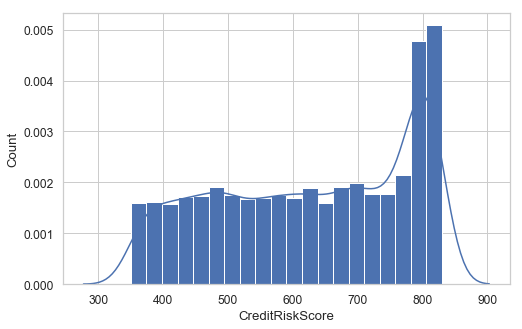

```python
import seaborn as sns

sns.set(style='whitegrid', palette="deep", font_scale=1.1, rc={"figure.figsize": [8, 5]})
sns.distplot(
    merged_df['CreditRiskScore'], norm_hist=False, kde=True, bins=20, hist_kws={"alpha": 1}
).set(xlabel='CreditRiskScore', ylabel='Count');
```

A credit risk score is a three-digit number that lenders use to determine how creditworthy you are. Credit scores range from 350-850. The higher the score, the more creditworthy you are. A score of 720+ is considered to be good. Here it is giving the credit_risk_score ranging from 350 to 830 and the count of credit score between 800 is 830 is highest,we can conclude that there are more customers whose credit score is between 800 to 850.

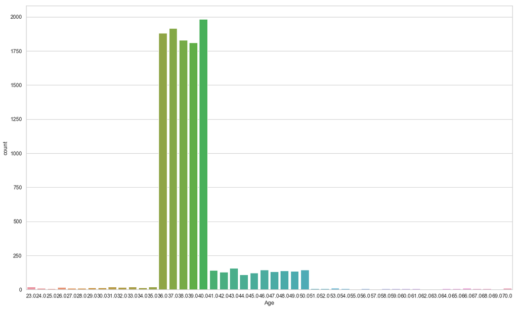

```python
plt.figure(figsize=(20,12))
sns.countplot(x="Age", data=merged_df)
plt.show()
```

##### The age group of customers is ranging from 23 to 70 most of the active customers are from the age group of 36 to 40.the count of the active customers which is the age group between 36 to 40 is about 1800 to 2000

### Histogram of numerical variables

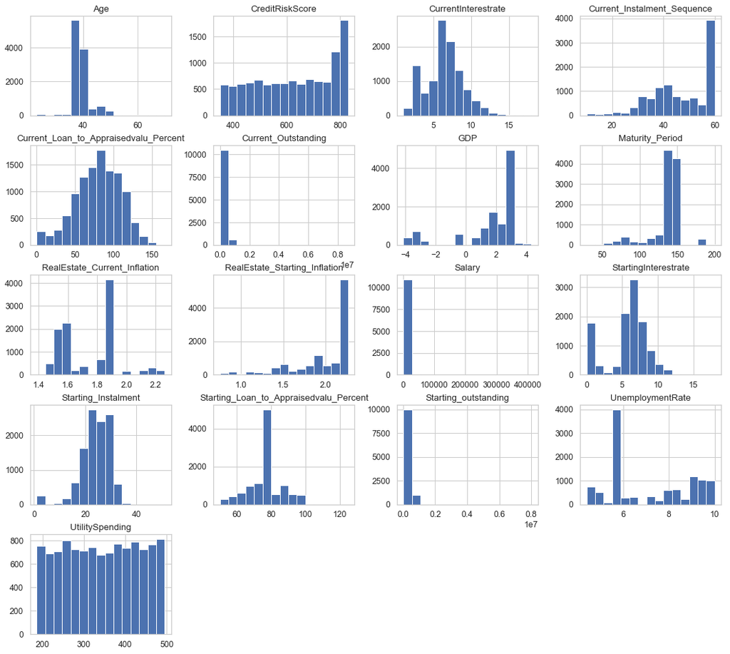

```python
merged_df[num_features].hist(bins=15, figsize=(18, 20), layout=(6, 4));
```

##### From the above plot we conclude that the CurrentOutstanding and startingOutstanding is right skewed(or positively skewed),Current_Loan_to_Appraisedvalu_Percent and Starting_Instalment are normally distibuted it also gives the range of all the numerical varianbles along with the count

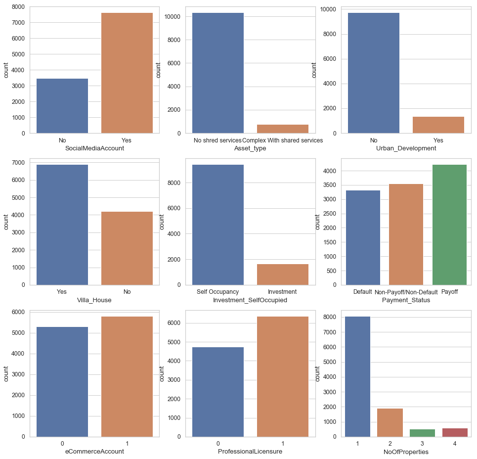

```python
fig, ax = plt.subplots(3, 3, figsize=(16, 16))
for variable, subplot in zip(cat_features, ax.flatten()):
    sns.countplot(merged_df[variable], ax=subplot)
```

```python
merged_df_num = merged_df.select_dtypes(include = ['float64', 'int64'])
merged_df_num.head()
```

| CustomerID | Age | Salary | ProfessionalLicensure | UtilitySpending | eCommerceAccount | NoOfProperties | CreditRiskScore | Current_Instalment_Sequence | Starting_Instalment | Maturity_Period | Current_Outstanding | Current_Loan_to_Appraisedvalu_Percent | CurrentInterestrate | RealEstate_Current_Inflation | GDP | UnemploymentRate | Starting_outstanding | Starting_Loan_to_Appraisedvalu_Percent | StartingInterestrate | RealEstate_Starting_Inflation |
| --- | --- | --- | --- | --- | --- | --- | --- | --- | --- | --- | --- | --- | --- | --- | --- | --- | --- | --- | --- | --- |
| C12116 | 50.0 | 1238.006112 | 0 | 492.726433 | 1 | 2 | 711 | 48 | 25 | 113 | 29087.21 | 26.658065 | 9.200 | 1.4645 | 2.715903 | 8.3 | 45000.0 | 69.4 | 9.20 | 0.8703 |
| C12117 | 38.0 | 1633.000000 | 1 | 477.870359 | 1 | 1 | 767 | 34 | 25 | 138 | 160044.34 | 73.431289 | 9.875 | 1.7335 | -0.314448 | 5.8 | 164500.0 | 70.0 | 7.50 | 1.8691 |
| C12118 | 49.0 | 1489.000000 | 0 | 351.593736 | 1 | 1 | 827 | 60 | 25 | 105 | 34562.30 | 16.897997 | 12.125 | 1.8982 | 2.836358 | 5.7 | 44000.0 | 52.5 | 13.00 | 0.7778 |
| C12119 | 43.0 | 1241.000000 | 0 | 403.589993 | 1 | 1 | 795 | 60 | 25 | 106 | 27355.73 | 18.466696 | 12.350 | 1.8982 | 2.836358 | 5.7 | 34800.0 | 56.9 | 12.35 | 0.7837 |
| C12120 | 44.0 | 1074.000000 | 1 | 406.066005 | 1 | 1 | 827 | 60 | 25 | 107 | 43102.83 | 18.516390 | 5.000 | 1.8982 | 2.836358 | 5.7 | 61600.0 | 64.3 | 9.25 | 0.7812 |

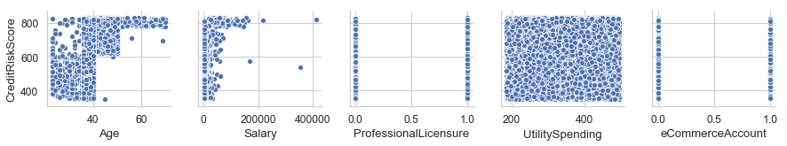

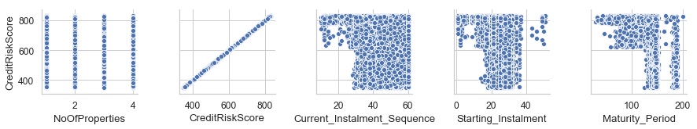

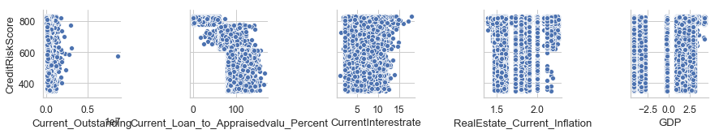

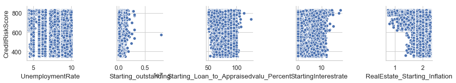

```python
for i in range(0, len(merged_df_num.columns), 5):
    sns.pairplot(data=merged_df_num,
                x_vars=merged_df_num.columns[i:i+5],
                y_vars=['CreditRiskScore'])
```

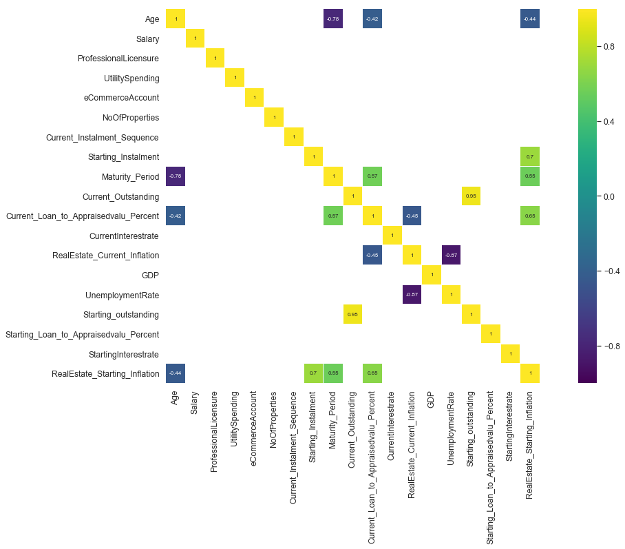

```python
corr =merged_df_num.drop('CreditRiskScore', axis=1).corr() # We already examined SalePrice correlations
plt.figure(figsize=(20, 10))

sns.heatmap(corr[(corr >= 0.5) | (corr <= -0.4)],
            cmap='viridis', vmax=1.0, vmin=-1.0, linewidths=0.1,
            annot=True, annot_kws={"size": 8}, square=True);
```

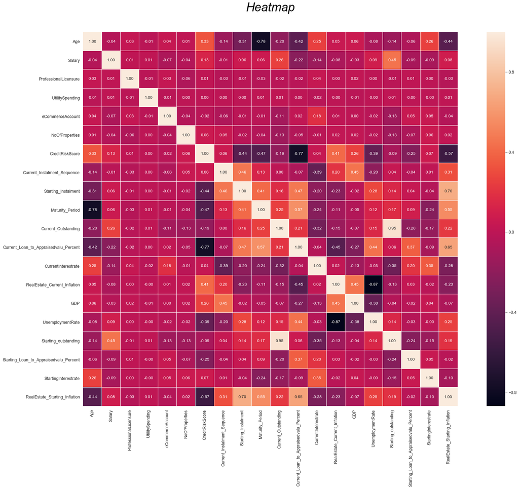

```python
correlation_matrix = merged_df.corr().round(2)
# annot = True to print the values inside the square
#plt.figure(figsize=(8, 8))  fmt="d"
plt.rcParams['font.size'] = 20
fig, ax = plt.subplots(figsize=(30,20))# Sample figsize in inchesTrue
#title for heatmap
title = "Heatmap"
plt.title(title, fontsize = 35,color='Black', fontstyle='italic')
ttl = ax.title
ttl.set_position([0.5, 1.05])
p=sns.heatmap(data=correlation_matrix, annot=True, fmt=".2f", linewidths=0.005, ax=ax, square=True, annot_kws={"size": 12})
plt.show()
```

##### from the above heat map we can see '' Current_Outstandng" and starting_Outstanding is 95% positively correlated And 'Maturity_Period' is negatively correlated with 'Age' and also 'Current_Loan_to_Appraisedvalu_Percent' is positively correlated with 'RealEstate_Starting_Inflation '

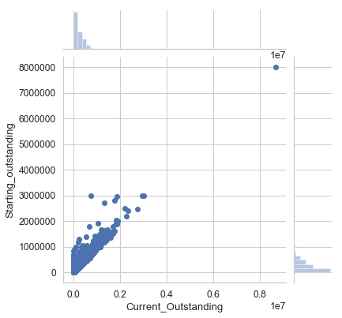

```python
sns.jointplot(x=merged_df['Current_Outstanding'], y=merged_df['Starting_outstanding'])
```

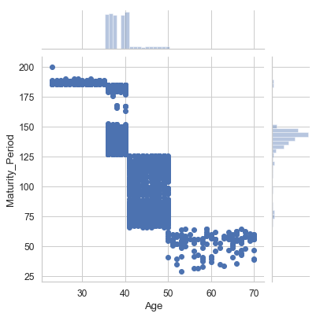

```python
sns.jointplot(x=merged_df['Age'], y=merged_df['Maturity_Period']); ## negatively correlated
```

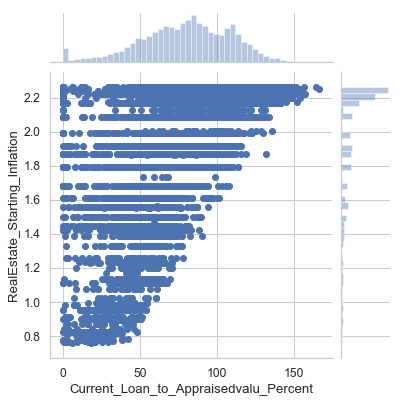

```python
sns.jointplot(x=merged_df['Current_Loan_to_Appraisedvalu_Percent'], y=merged_df['RealEstate_Starting_Inflation']);
```

```
[Text(0,0.5,'Count'), Text(0.5,0,'GDP')]
```

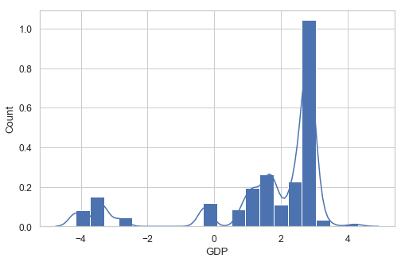

```python
import seaborn as sns

sns.set(style='whitegrid', palette="deep", font_scale=1.1, rc={"figure.figsize": [8, 5]})
sns.distplot(
    merged_df['GDP'], norm_hist=False, kde=True, bins=20, hist_kws={"alpha": 1}
).set(xlabel='GDP', ylabel='Count')
```

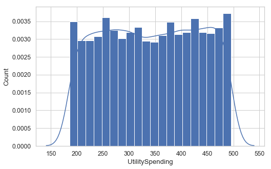

```python
import seaborn as sns

sns.set(style='whitegrid', palette="deep", font_scale=1.1, rc={"figure.figsize": [8, 5]})
sns.distplot(
    merged_df['UtilitySpending'], norm_hist=False, kde=True, bins=20, hist_kws={"alpha": 1}
).set(xlabel='UtilitySpending', ylabel='Count');
```

##### Utility spending is distibuted from values 200 to 500 and is above 0.0025 in count

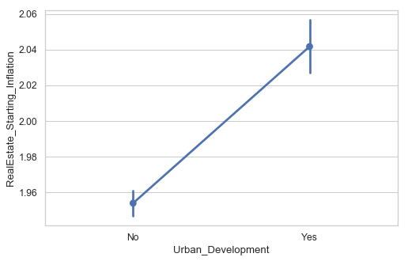

```python
sns.pointplot(x='Urban_Development', y='RealEstate_Starting_Inflation', data=merged_df)
```

#### At the starting point of resl estate inflation there will be no urban development.The urban development goes high with highest starting point of real estate inflation

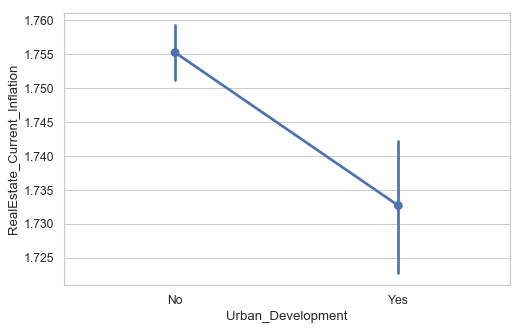

```python
sns.pointplot(x='Urban_Development', y='RealEstate_Current_Inflation', data=merged_df)
```

#### When there is no urban_development the realestate_current_inflation for current period is significantly high.

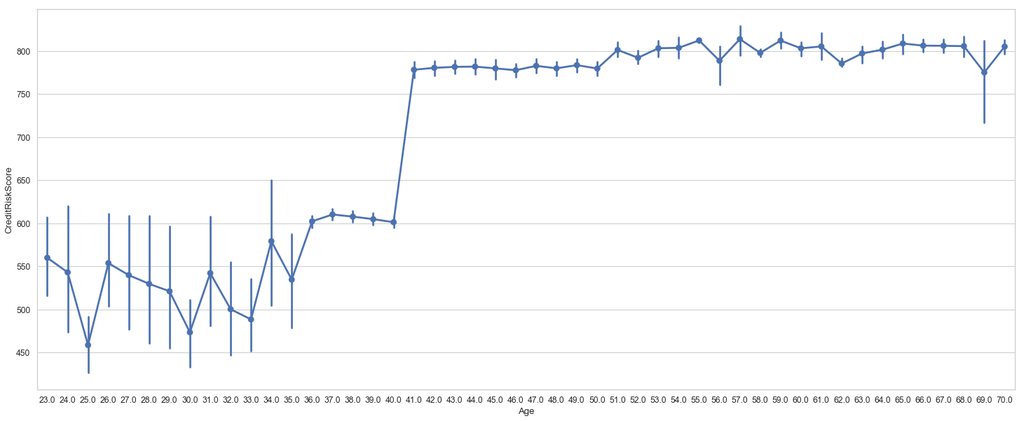

```python
plt.figure(figsize=(25,10))
sns.pointplot(x="Age", y="CreditRiskScore", data=merged_df)
```

##### We can interpret that as the from the age of 23 to 40 that is with the credit score range of 450 to almost 650 ,it is constant for 36 to 40 , above 40 the credict risk score is 750-800

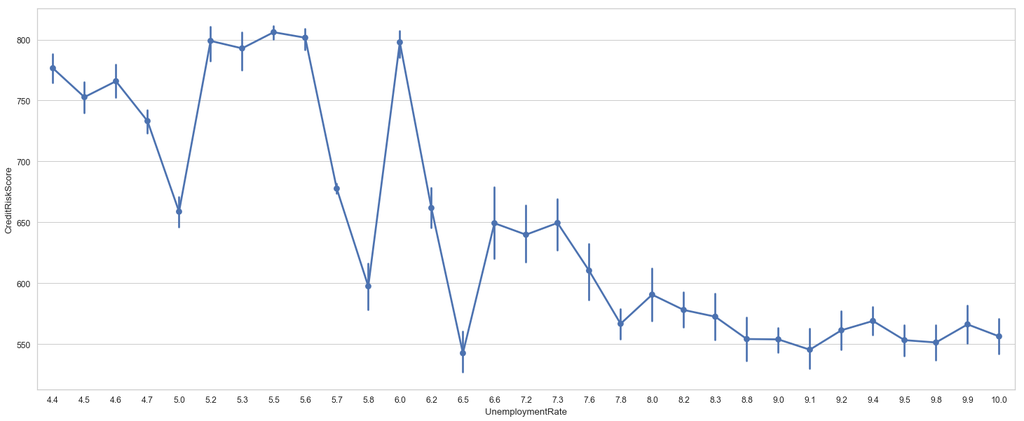

```python
plt.figure(figsize=(25,10))
ax = sns.pointplot(x="UnemploymentRate", y="CreditRiskScore", data=merged_df)
```

##### As the credit score decresases as the unemployement rate increases

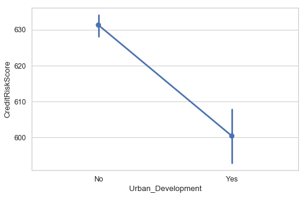

```python
ax = sns.pointplot(x="Urban_Development", y="CreditRiskScore", data=merged_df)
```

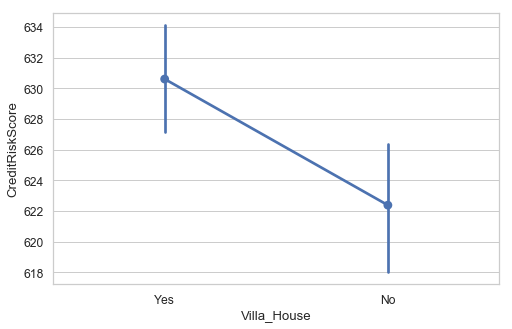

```python
sns.pointplot(x="Villa_House", y="CreditRiskScore", data=merged_df)
```

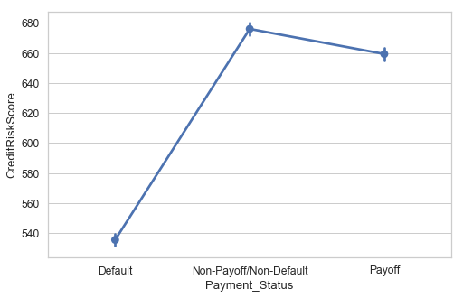

```python
sns.pointplot(x="Payment_Status", y="CreditRiskScore", data=merged_df)
```

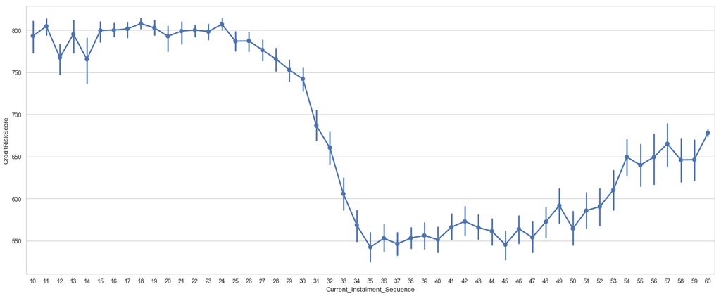

```python
plt.figure(figsize=(25,10))
sns.pointplot(x="Current_Instalment_Sequence", y="CreditRiskScore", data=merged_df)
```

#### The creditRiskScore is constant when the current_Investment_Sequence is in the range between 10-26,when the current_Investment_Sequence incresed after 26 the credit score started descreasing again after 35 it started increasing slowly.

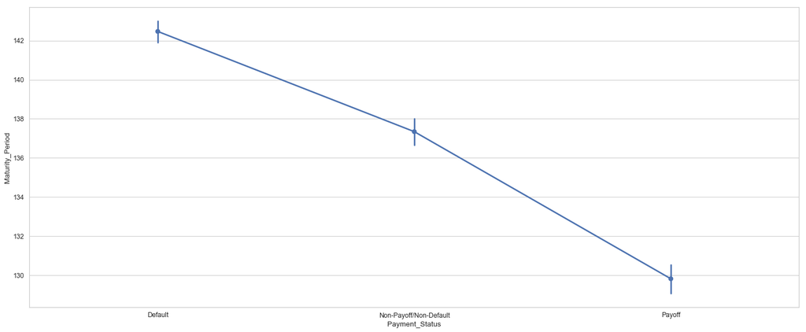

```python
plt.figure(figsize=(25,10))
sns.pointplot(x="Payment_Status", y="Maturity_Period", data=merged_df)
```

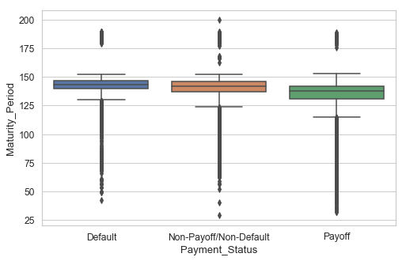

```python
sns.boxplot(x="Payment_Status", y="Maturity_Period", data=merged_df)
```

#### Maturity period increases with default payment status and for payoff payment status maturity period is significantly low,for non paymnet/non default payment status maturity period is between 136 to 138

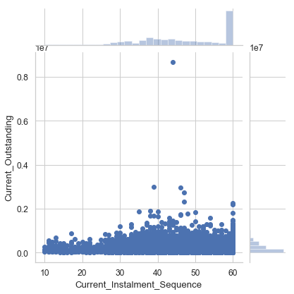

```python
sns.jointplot(x=merged_df['Current_Instalment_Sequence'], y=merged_df['Current_Outstanding']);
```